# Dark Blue Theme Example

quarto

styling

customization

dark-theme

Author

Guillaume Noblet

Published

December 20, 2023

# Dark Blue Theme for Quarto Documents

This document demonstrates how to use a custom dark blue theme in Quarto that matches the website’s color palette. The theme provides a consistent visual experience with dark backgrounds and a blue accent color scheme.

## Theme Features

The dark blue theme includes:

- Dark backgrounds with blue accents
- Optimized code highlighting for dark mode
- Custom styled tables and callouts
- Typography that matches the main website
- Proper color contrast for readability

## Code Examples

Here’s how code blocks look in this theme:

```python
# A simple Python function
def calculate_fibonacci(n):
    """Calculate the Fibonacci sequence up to n"""
    fib = [0, 1]
    while len(fib) < n:
        fib.append(fib[-1] + fib[-2])
    return fib

# Generate first 10 Fibonacci numbers
fibonacci = calculate_fibonacci(10)
print(f"Fibonacci sequence: {fibonacci}")
```

And here’s some R code with execution:

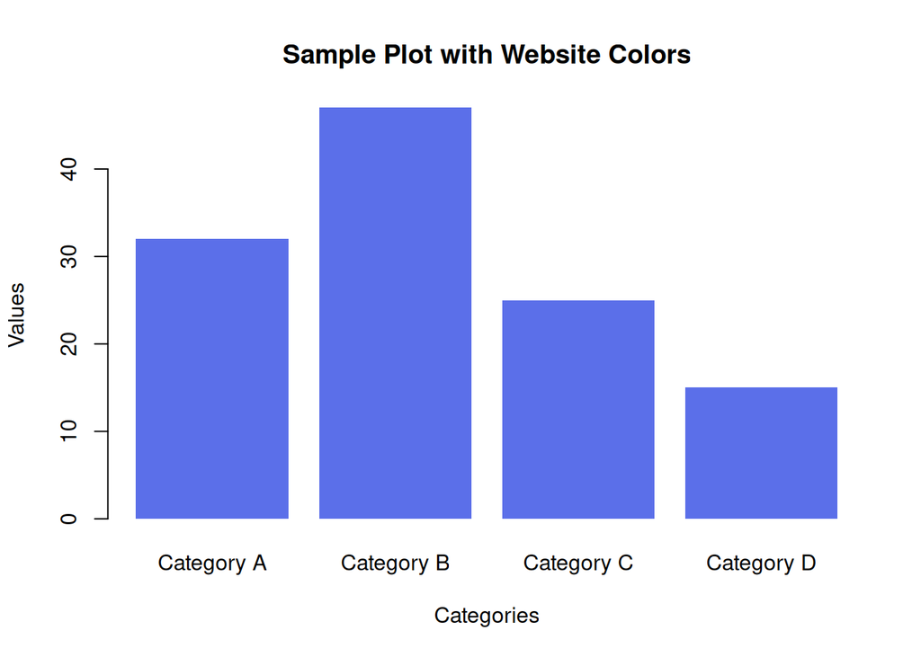

Bar plot with website color palette

```r
# Create a simple dataset
categories <- c("Category A", "Category B", "Category C", "Category D")
values <- c(32, 47, 25, 15)

# Create a bar plot
barplot(values,
        names.arg = categories,
        col = "#5B6FE9",
        border = NA,
        main = "Sample Plot with Website Colors",
        xlab = "Categories",
        ylab = "Values")
```

## Tables

Tables are styled to match the dark theme:

| Feature | Description | Status |
| --- | --- | --- |
| Dark background | Main document background | ✓ |
| Code highlighting | Syntax colors optimized for dark mode | ✓ |
| Tables | Styled with theme-appropriate colors | ✓ |
| Math equations | Support for LaTeX math | ✓ |
| Diagrams | Support for mermaid and other diagrams | ✓ |

## Callouts

Here are examples of callouts with the dark blue theme styling:

**Note**

This is a note callout styled to match the website theme.

**Tip**

This is a tip callout with styling that matches the accent colors.

**Warning**

This is a warning callout with appropriate warning colors.

**Important**

This is an important callout with attention-grabbing styling.

## Mathematical Equations

The theme properly handles mathematical equations:

$$f(x) = \int_{-\infty}^{\infty} \hat{f}(\xi) e^{2\pi i \xi x} d\xi$$

Inline equations like $E = mc^2$ are also styled appropriately.

## Diagrams

The dark theme works well with diagrams:

[output not shown]

## Using This Theme

To use this dark blue theme in your own Quarto documents, add these lines to your document’s YAML header:

```yaml
format:
  html:
    theme: templates/website-dark-blue.scss
    minimal: true
    page-layout: article
    toc: true
```

## Benefits of the Dark Blue Theme

Using this theme offers several advantages:

1. **Reduced eye strain** - Dark mode is easier on the eyes, especially at night
2. **Visual consistency** - Maintains the brand identity of the main website
3. **Improved code readability** - Syntax highlighting optimized for dark backgrounds
4. **Professional appearance** - Polished, modern look for technical content

## Conclusion

The dark blue theme provides a consistent visual experience that aligns with the main website’s design while offering excellent readability for technical content. It’s particularly well-suited for code-heavy documents and presentations that will be viewed in low-light environments.